# **Attribute Information**

## Netflix has more focus on TV Shows than movies in recent years

```python
df_type= df_netflix.groupby(["release_year","type"]).agg({"title":"nunique"}).reset_index().sort_values(by="title",ascending=False).head(21)
df_type=df_type[df_type["release_year"]>=2012]
df_type
```

|  | release_year | type | title |
| --- | --- | --- | --- |
| 140 | 2018 | Movie | 767 |
| 138 | 2017 | Movie | 765 |
| 136 | 2016 | Movie | 658 |
| 142 | 2019 | Movie | 633 |
| 144 | 2020 | Movie | 517 |
| 145 | 2020 | TV Show | 436 |
| 143 | 2019 | TV Show | 397 |
| 134 | 2015 | Movie | 396 |
| 141 | 2018 | TV Show | 379 |
| 147 | 2021 | TV Show | 315 |
| 146 | 2021 | Movie | 277 |
| 139 | 2017 | TV Show | 265 |
| 132 | 2014 | Movie | 264 |
| 137 | 2016 | TV Show | 243 |
| 130 | 2013 | Movie | 225 |
| 128 | 2012 | Movie | 173 |
| 135 | 2015 | TV Show | 159 |

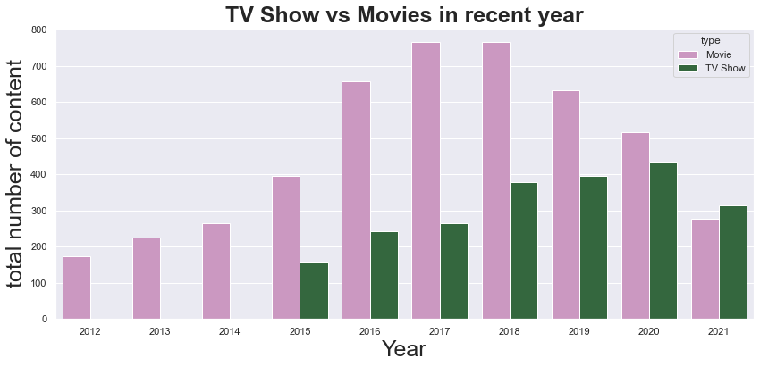

```python
sns.set(style="darkgrid")
plt.figure(figsize=(14,6))
sns.barplot(x='release_year',y='title',data=df_type,hue="type", palette="cubehelix_r")
plt.title("TV Show vs Movies in recent year",size='25',fontweight="bold")
plt.xlabel("Year",fontsize=25)
plt.ylabel("total number of content",fontsize=25)
plt.show()
```

- **Netflix has been focusing more on television shows in recent years than films, which appears to be gaining popularity among viewers.**

# Content available in different countries

### (a) Top Content available countries

```python
df_country= df_netflix.groupby(["country"]).agg({"title":"nunique"}).reset_index().sort_values(by="title",ascending=False).head(16)
df_country=df_country[df_country["country"]!="Unknown country"]
```

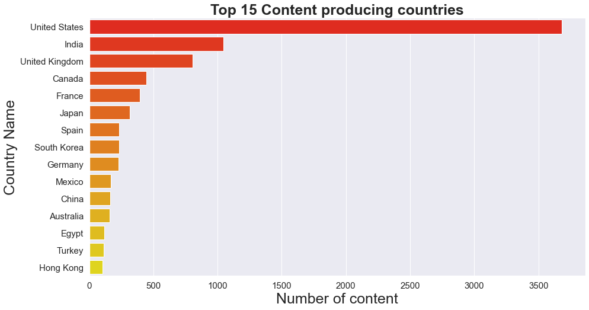

```python
sns.set(style="darkgrid")
plt.figure(figsize=(15,8))
sns.barplot(y='country',x='title',data=df_country,palette="autumn")
plt.title("Top 15 Content producing countries",size='25',fontweight="bold")
plt.ylabel("Country Name",fontsize=25)
plt.xlabel("Number of content",fontsize=25)
plt.xticks(fontsize=15)
plt.yticks(fontsize=15)
plt.show()
```

- **There are a majority of content providers in the countries listed above.**
- **On the platform, more than half of the television shows and movies are created in the USA, India, and the United Kingdom.**

## (b) Countriwise content

```python
df_top7=df_netflix.groupby(["country", "type"]).size().reset_index(name="count")
df_new_data=df_top7[(df_top7['country'] != "India") & (df_top7['country'] != "United States") &
         (df_top7['country'] != "United df_top7ingdom") & (df_top7['country'] != "Canada") &
         (df_top7['country'] != "France") & (df_top7['country'] != "Japan") & (df_top7['country'] != "Spain") &
              (df_top7['country'] != "South Korea")].index

df_data7_country=df_top7.drop(df_new_data)
```

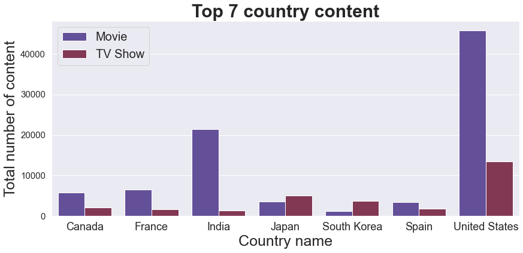

```python
sns.set(style="darkgrid")
plt.figure(figsize=(14,6))
sns.barplot(x='country',y='count',data=df_data7_country,hue="type", palette="twilight")
plt.title("Top 7 country content",size=30,fontweight="bold")
plt.xlabel("Country name",fontsize=25)
plt.ylabel("Total number of content",fontsize=25)
plt.legend(fontsize=20,loc="upper left")
plt.xticks(fontsize=18)
plt.yticks(fontsize=15)
plt.show()
```

- **South Korea and Japan are the only two countries in the top 7 that produce more TV shows.**
- **Out of all countries, the United States is the one that produces the most movies and TV shows.**
- **There are not enough TV shows in India compared to movies.**

## (c) different type of Genre in top content producing countries - Correlation(Heatmaps)

```python
df_top=df_netflix.groupby(["country", "Genre"]).size().reset_index(name="count")
df_new=df_top[(df_top['country'] != "India") & (df_top['country'] != "United States") &
         (df_top['country'] != "United df_topingdom") & (df_top['country'] != "Canada") &
         (df_top['country'] != "France") & (df_top['country'] != "Japan") & (df_top['country'] != "Spain") &
              (df_top['country'] != "South Korea")].index

df_data_country=df_top.drop(df_new)

df_heatmap=df_data_country.pivot(index='country', columns='Genre', values='count')

for genre in df_heatmap.columns:

    if (genre != "International Movies") & (genre!= "Dramas") & (genre!= "Comedies") & (genre != "International TV Shows") & (genre!= "Documentaries") & (genre != "Action & Adventure"):
        df_heatmap=df_heatmap.drop(genre, axis=1)
df_heatmap
```

| Genre country | Action & Adventure | Comedies | Documentaries | Dramas | International Movies | International TV Shows |
| --- | --- | --- | --- | --- | --- | --- |
| Canada | 432.0 | 1017.0 | 95.0 | 793.0 | 437.0 | 177.0 |
| France | 378.0 | 567.0 | 116.0 | 1708.0 | 1740.0 | 430.0 |
| India | 1187.0 | 2685.0 | 32.0 | 5569.0 | 7059.0 | 428.0 |
| Japan | 823.0 | 128.0 | 19.0 | 208.0 | 810.0 | 1787.0 |
| South Korea | 141.0 | 205.0 | 2.0 | 213.0 | 333.0 | 1184.0 |
| Spain | 99.0 | 476.0 | 50.0 | 691.0 | 1131.0 | 597.0 |
| United States | 4508.0 | 8385.0 | 1205.0 | 8173.0 | 1211.0 | 638.0 |

```python
df_heatmap
```

| Genre country | Action & Adventure | Comedies | Documentaries | Dramas | International Movies | International TV Shows |
| --- | --- | --- | --- | --- | --- | --- |
| Canada | 432.0 | 1017.0 | 95.0 | 793.0 | 437.0 | 177.0 |
| France | 378.0 | 567.0 | 116.0 | 1708.0 | 1740.0 | 430.0 |
| India | 1187.0 | 2685.0 | 32.0 | 5569.0 | 7059.0 | 428.0 |
| Japan | 823.0 | 128.0 | 19.0 | 208.0 | 810.0 | 1787.0 |
| South Korea | 141.0 | 205.0 | 2.0 | 213.0 | 333.0 | 1184.0 |
| Spain | 99.0 | 476.0 | 50.0 | 691.0 | 1131.0 | 597.0 |
| United States | 4508.0 | 8385.0 | 1205.0 | 8173.0 | 1211.0 | 638.0 |

```python
df_top
```

|  | country | Genre | count |
| --- | --- | --- | --- |
| 0 |  | Dramas | 8 |
| 1 |  | Independent Movies | 8 |
| 2 |  | International Movies | 8 |
| 3 |  | International TV Shows | 4 |
| 4 |  | TV Dramas | 4 |
| ... | ... | ... | ... |
| 1459 | West Germany | Thrillers | 10 |
| 1460 | Zimbabwe | Comedies | 12 |
| 1461 | Zimbabwe | Documentaries | 3 |
| 1462 | Zimbabwe | International Movies | 15 |
| 1463 | Zimbabwe | Romantic Movies | 12 |

1464 rows × 3 columns

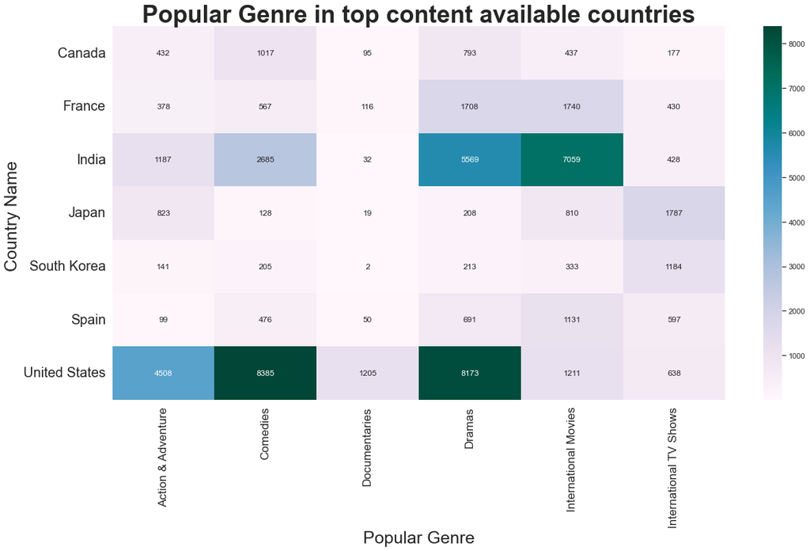

```python
plt.figure(figsize=(20,10))
sns.heatmap(df_heatmap,cmap="PuBuGn",annot=True,fmt=".0f")
plt.title("Popular Genre in top content available countries",size=35,fontweight="bold")
plt.xlabel("Popular Genre",fontsize=25)
plt.ylabel("Country Name ",fontsize=25)
plt.xticks(fontsize=17,rotation=90)
plt.yticks(fontsize=20,rotation=0)
plt.show()
```

## (d) Popular content Rating country

```python
df_top_rating=df_netflix.groupby(["country", "rating"]).size().reset_index(name="count")
df_rating=df_top_rating[(df_top_rating['country'] != "India") & (df_top_rating['country'] != "United States") &
         (df_top_rating['country'] != "United df_top_ratingingdom") & (df_top_rating['country'] != "Canada") &
         (df_top_rating['country'] != "France") & (df_top_rating['country'] != "Japan") & (df_top_rating['country'] != "Spain") &
              (df_top_rating['country'] != "South Korea")].index

df_data_rating=df_top_rating.drop(df_rating)

df_heatmap_rating=df_data_rating.pivot(index='country', columns='rating', values='count')

df_heatmap_rating
```

| rating country | G | NC-17 | NR | PG | PG-13 | R | TV-14 | TV-G | TV-MA | TV-PG | TV-Y | TV-Y7 | TV-Y7-FV | UR |
| --- | --- | --- | --- | --- | --- | --- | --- | --- | --- | --- | --- | --- | --- | --- |
| Canada | 48 | 20 | 54 | 1034 | 639 | 1496 | 758 | 314 | 2009 | 556 | 485 | 478 | 24 | 0 |
| France | 36 | 39 | 72 | 643 | 768 | 1366 | 685 | 37 | 3908 | 259 | 116 | 280 | 0 | 45 |
| India | 0 | 0 | 132 | 159 | 233 | 102 | 12341 | 113 | 6324 | 3194 | 51 | 161 | 4 | 0 |
| Japan | 30 | 0 | 0 | 268 | 338 | 227 | 2615 | 28 | 3102 | 1380 | 29 | 582 | 0 | 0 |
| South Korea | 28 | 0 | 46 | 40 | 16 | 48 | 2052 | 6 | 2019 | 399 | 89 | 300 | 0 | 0 |
| Spain | 74 | 39 | 42 | 86 | 80 | 235 | 275 | 3 | 4302 | 106 | 17 | 56 | 0 | 0 |
| United States | 907 | 12 | 453 | 6002 | 9144 | 13478 | 6184 | 1044 | 14985 | 2991 | 1546 | 2462 | 34 | 20 |

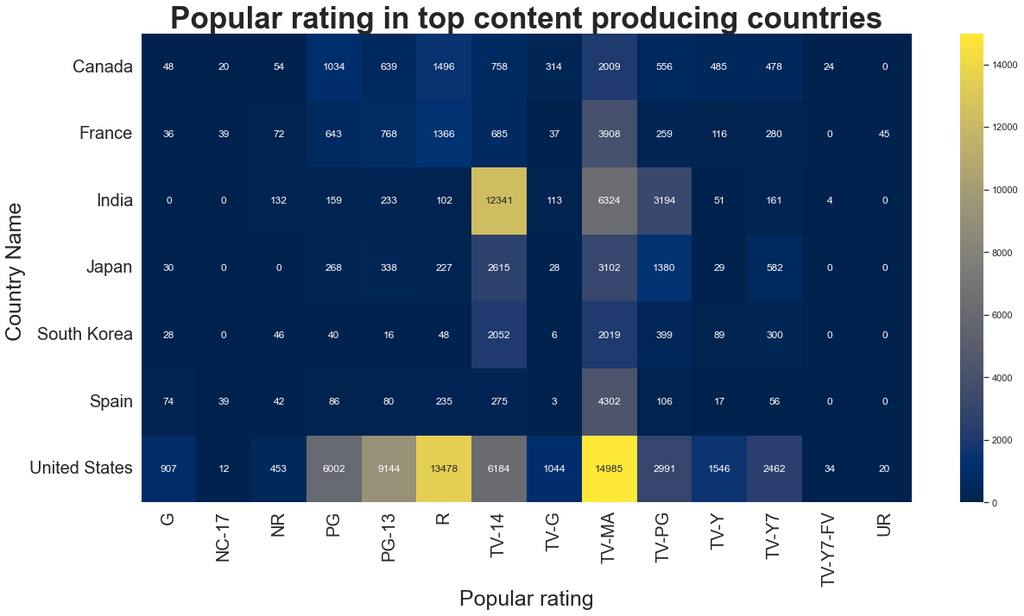

```python
plt.figure(figsize=(20,10))
sns.heatmap(df_heatmap_rating,cmap="cividis",annot=True,fmt=".0f")
plt.title("Popular rating in top content producing countries",size=35,fontweight="bold")
plt.xlabel("Popular rating",fontsize=25)
plt.ylabel("Country Name ",fontsize=25)
plt.xticks(fontsize=20,rotation=90)
plt.yticks(fontsize=20,rotation=0)
plt.show()
```

## Categorical: Boxplot

```python
# type is a categorcal Dtype
```

```python
df_netflix.type.dtype
```

```
CategoricalDtype(categories=['Movie', 'TV Show'], ordered=False)
```

```python
df_cat_type= df_netflix.groupby(["type","release_year"]).agg({"title":"nunique"}).reset_index().sort_values(by="title",ascending=False)
df_cat_type=df_cat_type[df_cat_type["release_year"]>=1990]
```

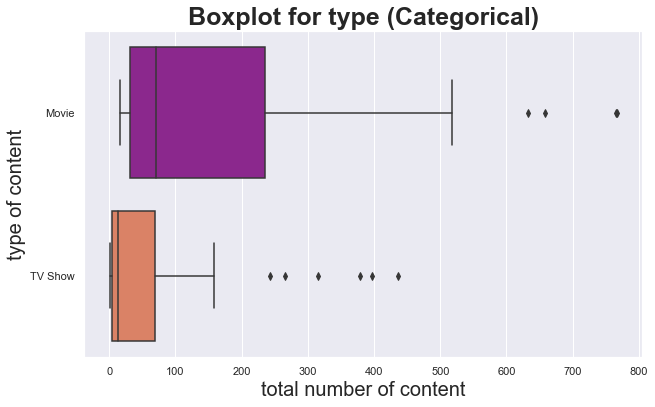

```python
plt.figure(figsize=(10,6))
sns.boxplot(y="type",x='title',data=df_cat_type,palette="plasma")
plt.title("Boxplot for type (Categorical)",size=25,fontweight="bold")
plt.ylabel("type of content",fontsize=20)
plt.xlabel("total number of content",fontsize=20)
plt.show()
```

- **From 1990 to present, the median of total content in movies has been higher than the median of total content in television shows.**
- **There has been an increase in production for movies and TV shows in the recent year, so this is why it's showing as an outliner.**

# Correlation-Pairplot

*As we know pairplot is a pairwise relationships in a dataset. This creats a nice visualisation and helps us understand the data by summarising a large amount of data in a single figure.*

```python
df_new= df_netflix.groupby(["release_year","Month","date_added","type"]).agg({"title":"nunique"}).reset_index().sort_values(by="title",ascending=False)
df_final=df_new.rename(columns={"title":"count"})
df_final["Month_added"]=df_final["date_added"].dt.month
df_final=df_final[df_final["release_year"]>=2015].head(300)
```

```python
df_final
```

|  | release_year | Month | date_added | type | count | Month_added |
| --- | --- | --- | --- | --- | --- | --- |
| 2855170 | 2017 | July | 2018-07-01 | Movie | 17 | 7 |
| 2861836 | 2017 | March | 2018-03-01 | Movie | 14 | 3 |
| 2865360 | 2017 | May | 2018-05-01 | Movie | 14 | 5 |
| 2851466 | 2017 | January | 2018-01-01 | Movie | 14 | 1 |
| 2855830 | 2017 | July | 2019-07-01 | Movie | 13 | 7 |
| ... | ... | ... | ... | ... | ... | ... |
| 3014503 | 2021 | February | 2021-02-24 | TV Show | 4 | 2 |
| 2789678 | 2015 | October | 2017-10-15 | Movie | 4 | 10 |
| 2858554 | 2017 | June | 2018-06-01 | Movie | 4 | 6 |
| 2816899 | 2016 | June | 2017-06-10 | TV Show | 4 | 6 |
| 2886318 | 2018 | December | 2018-12-28 | Movie | 4 | 12 |

300 rows × 6 columns

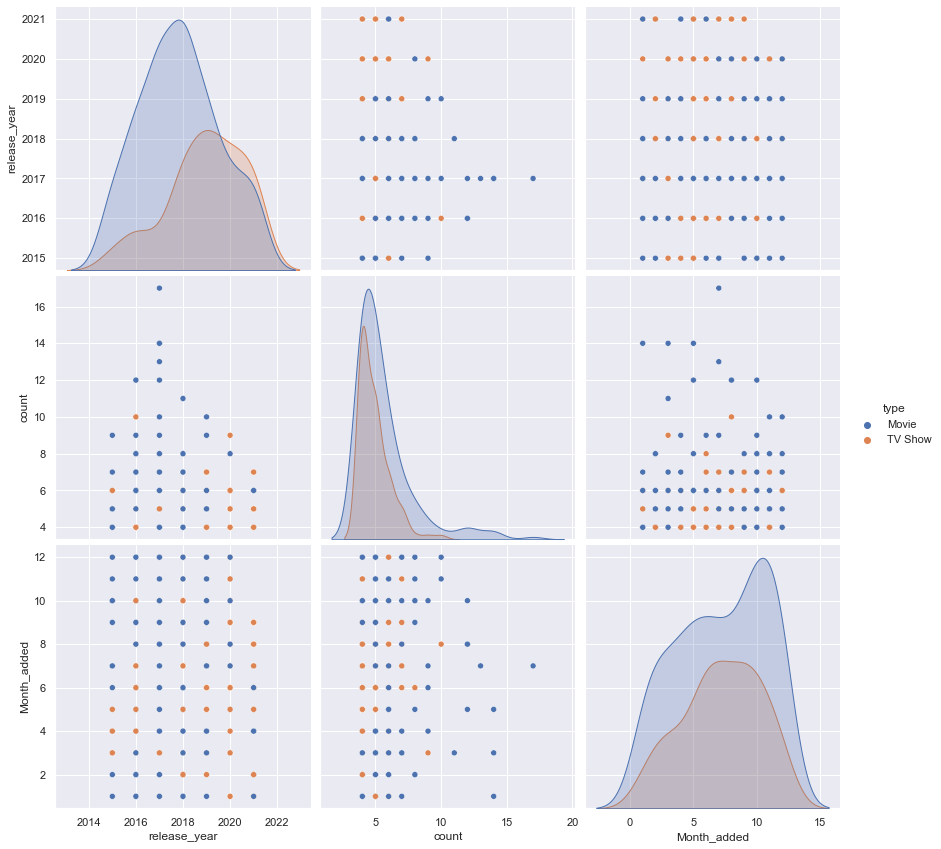

```python
sns.set(style="darkgrid")
sns.pairplot(data=df_final,hue="type",size=4)
plt.show()
```

- **On this plot, we will be able to analyze month_added, count, and released year data.we can see clearly in above figuer**
- **During the past few years, television show production has increased and movie production has declined slightly due to covid 19.**

# Content Rating per Year (Heatmap)

```python
df_new2=df[df["release_year"]>=2014]
df_rating_year=df_new2.groupby("release_year").rating.value_counts().unstack().fillna(0).T
```

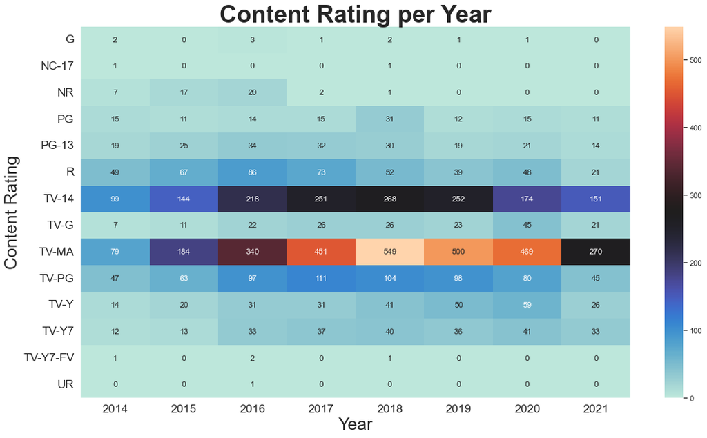

```python
plt.figure(figsize=(18,10))
sns.heatmap(df_rating_year,cmap="icefire",annot=True,fmt=".0f")
plt.title("Content Rating per Year",size=35,fontweight="bold")
plt.xlabel("Year",fontsize=25)
plt.ylabel("Content Rating",fontsize=25)
plt.xticks(fontsize=17)
plt.yticks(fontsize=17,rotation=0)
plt.show()
```

- **The most popular Netflix content is TV-MA, which indicates that mature content is more popular.**
- **Those shows are followed by TV-14 and TVPG, which are aimed at teens and older kids.**

## Outliers on release_year column

```python
df['release_year'].value_counts().to_frame().T
```

|  | 2018 | 2017 | 2019 | 2020 | 2016 | 2021 | 2015 | 2014 | 2013 | 2012 | ... | 1956 | 1965 | 1946 | 1942 | 1954 | 1959 | 1925 | 1961 | 1947 | 1966 |
| --- | --- | --- | --- | --- | --- | --- | --- | --- | --- | --- | --- | --- | --- | --- | --- | --- | --- | --- | --- | --- | --- |
| release_year | 1146 | 1030 | 1030 | 953 | 901 | 592 | 555 | 352 | 286 | 236 | ... | 2 | 2 | 2 | 2 | 2 | 1 | 1 | 1 | 1 | 1 |

1 rows × 74 columns

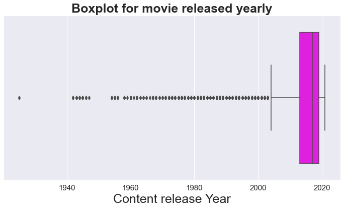

```python
plt.figure(figsize=(12,6))
sns.boxplot(data=df,x="release_year",color="magenta")
plt.title("Boxplot for movie released yearly",size=25,fontweight="bold")
plt.xlabel("Content release Year",fontsize=25)
plt.xticks(fontsize=15)
plt.show()
```

## Top 20 Genre on Netflix:

```python
df_top_genre= df_netflix.groupby(["Genre"]).agg({"title":"nunique"}).reset_index().sort_values(by="title",ascending=False).head(20)
```

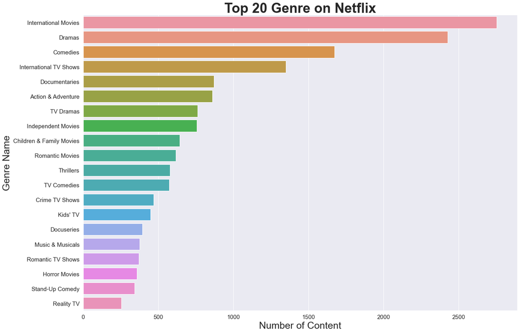

```python
plt.figure(figsize=(20,14))
sns.barplot(data=df_top_genre,y="Genre",x="title")
plt.title("Top 20 Genre on Netflix",size=35,fontweight="bold")
plt.xlabel("Number of Content",fontsize=25)
plt.ylabel("Genre Name",fontsize=25)
plt.yticks(fontsize=15)
plt.xticks(fontsize=15)
plt.show()
```

**Five most popular genres in recent years are International movies, Dramas, Comedies, International TV Shows and Documentaries.**

# Insights

# Recommendation

1. More movies are needed, as the number of movies has declined since 2018, while the number of television shows has increased.
2. Consider the popular actors and directors for that country when creating content, as well as the actor-director combination which is highly recommended.
3. It is recommended to watch TV shows in Japan and South Korea. The anime genre is popular in Japan, while the drama genre is popular in South Korea.
4. The content of international movies is recommended for indians with TV-14 rating.
5. Netflix should be focusing on adding more movies in emerging countries like India, United Kingdom, Canada and France for Adult audience.
6. It is recommended that comedies and dramas have more adults content for the USA audience.
7. Preferred Duration of movies will be from 80-120 minutes.